# Denominator + Nonsensical covariates combination + Network

## Denominator

**Question:** MNI cannot be interpreted as the population unless sampling was random, but it wasn’t. So what should be the denominator (First selection layer)?

**Before:** Using MNI to calculate the maximum number of pairs.

Problem:

- Numerator = # observed related pairs only come from the **analysed individuals**
- Using MNI creates sample selection bias, since we assume the population (MNI) have the similar kinship patterns with the analysed subset (the analysed subset is not randomly selected)

$\Rightarrow$ **# Analysed individuals** as denominator *(= “after merging samples from same individual”, column L in tomb_parameter)*

## Nonsensical covariate combinations

**Question:** Check for nonsensical covariate combinations to see if they are “even modelable” before running models.

### Check for nonsensical covariate combinations

#### Skeletal element

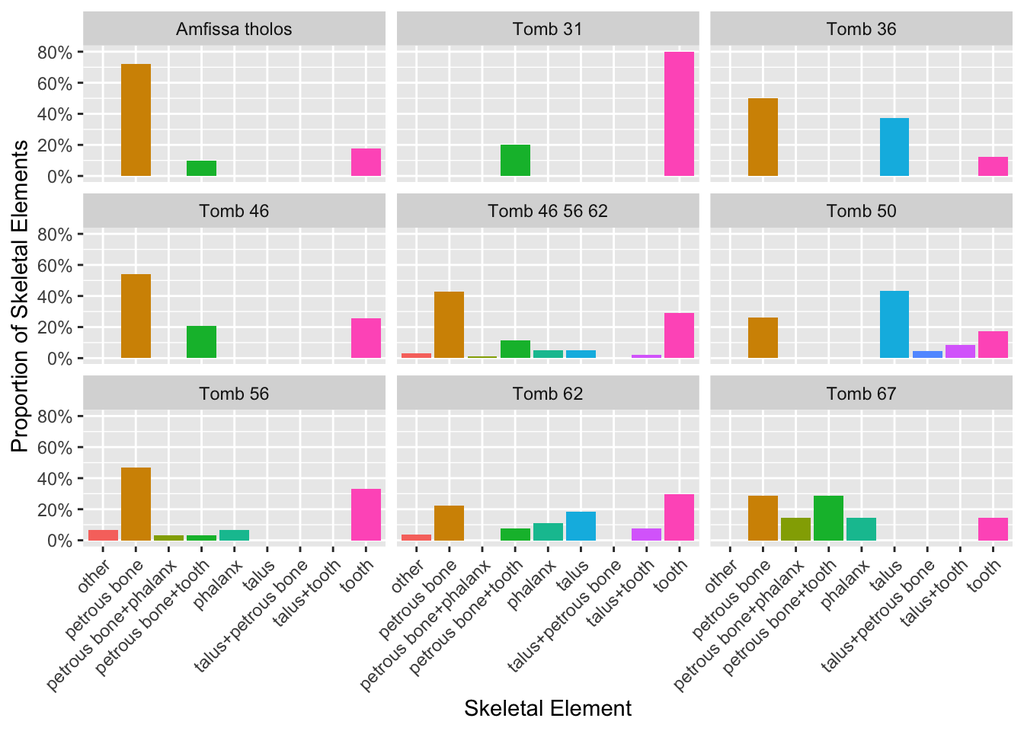

**Absolute number of skeletal element as Sex in every tomb**

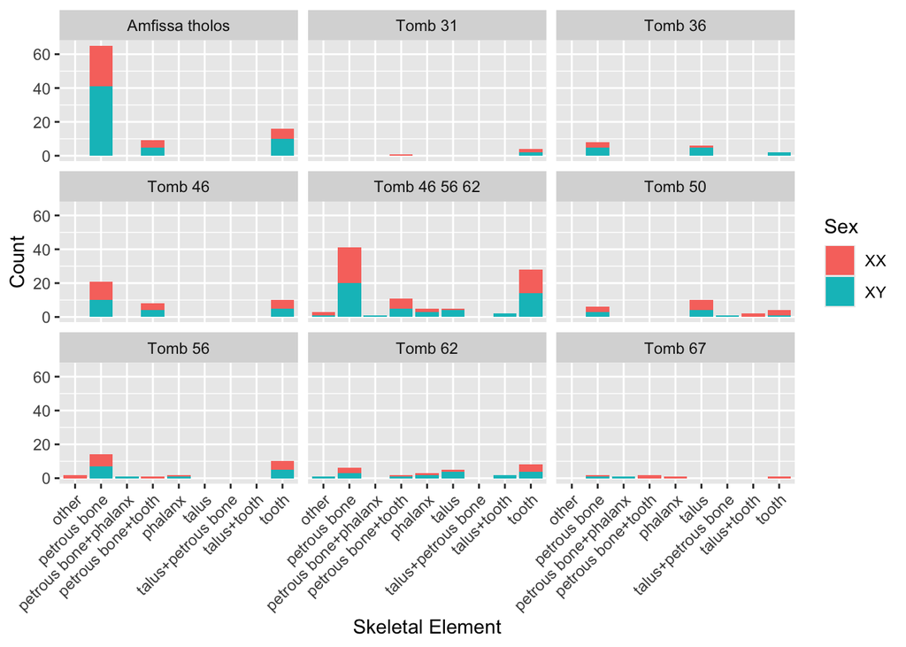

**Relative number of skeletal element as Sex in every tomb**

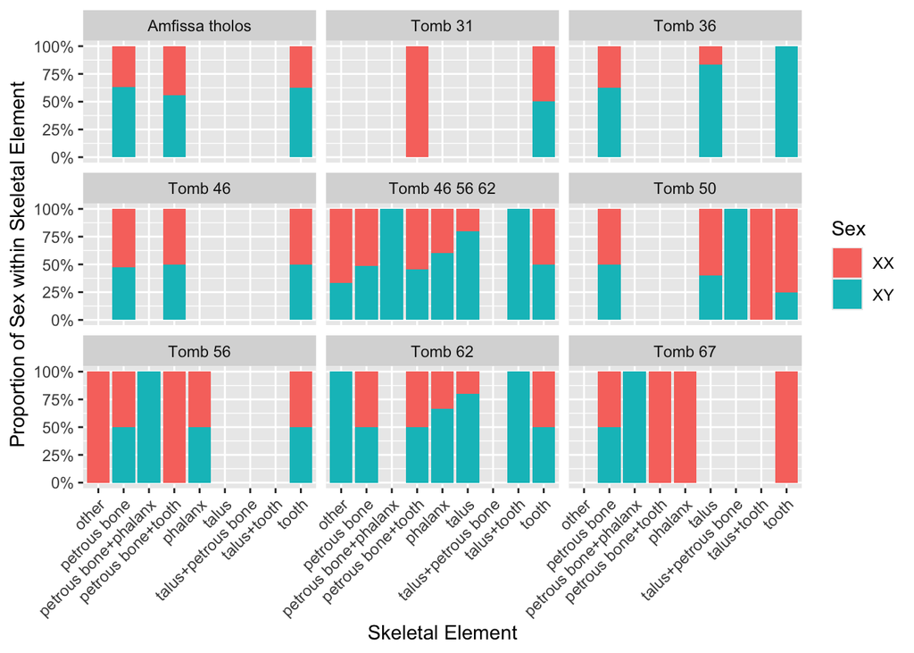

**Absolute number of skeletal element as Age in every tomb**

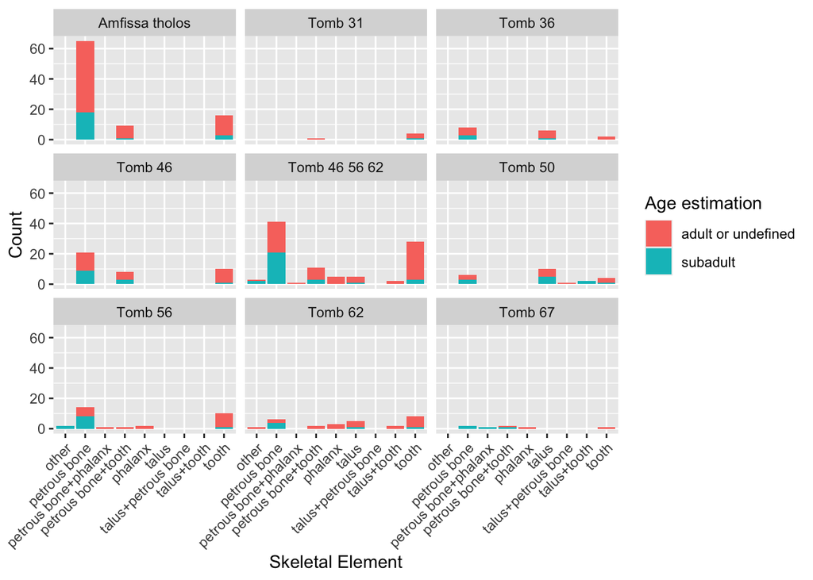

**Relative number of skeletal element as Age in every tomb**

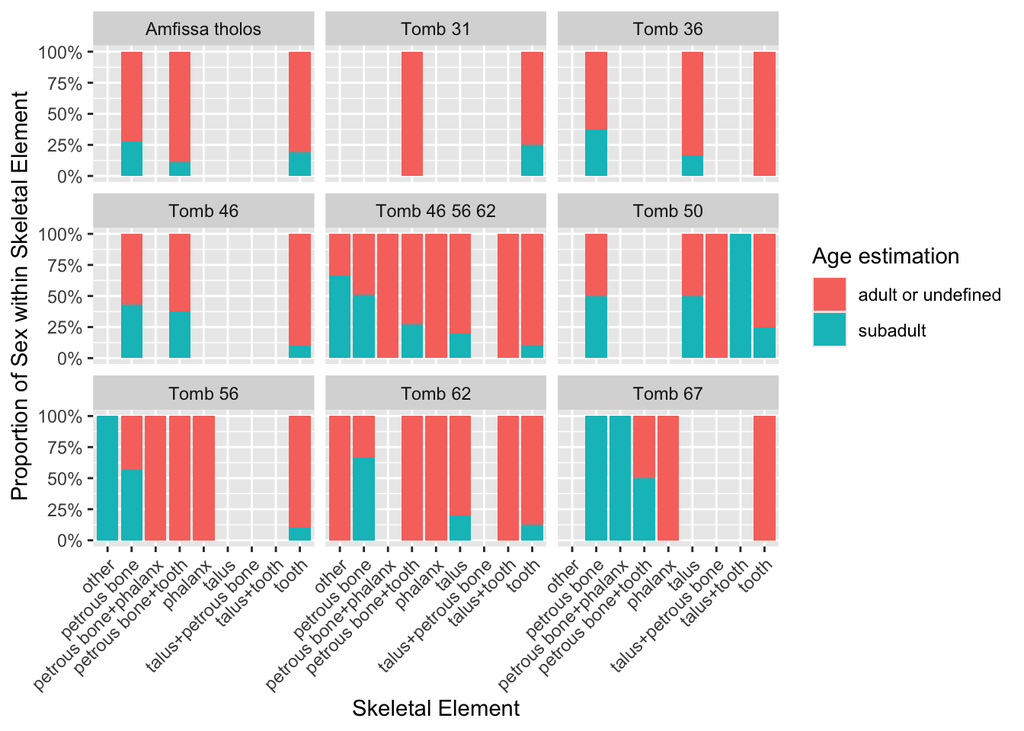

**Absolute and Relative number of Sex as Age in every tomb**

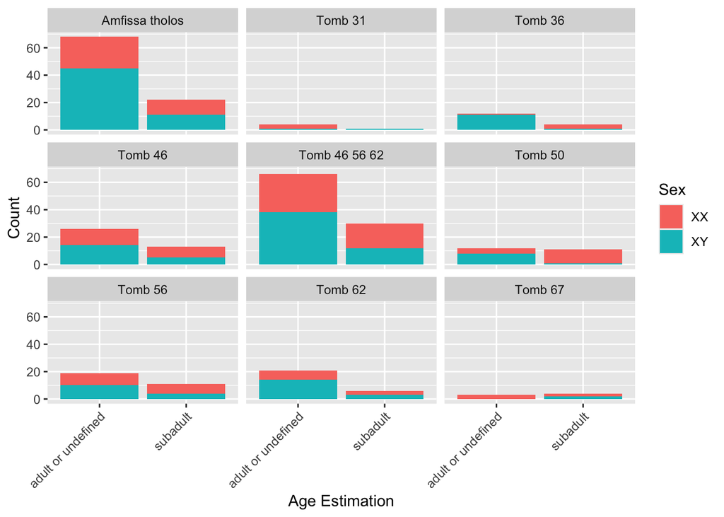

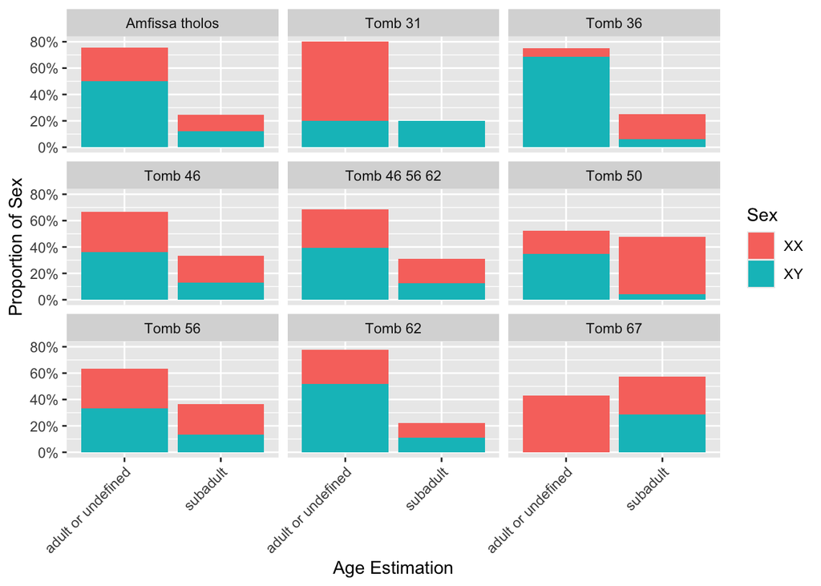

#### Problems:

Sparse data. In some tombs:

- lack certain skeletal elements
- some skeletal elements only appear in one sex or age

$\Rightarrow$ Problem:

- Unstable model, effect of the missing skeletal element can not be estimated for that tomb
- Collinearity: eg. Tomb 67 has only female phalanx $\Rightarrow$ perfect collinearity between skeletal element & sex?

Previous problem with the GLM logistic model:

- With-in tomb correlation (same preservation environment,…)
- Too many parameters with too few observation (tomb-level data set)

**Solution:** Mixed logistic modelling on individual-level data. Especially GLMM can handle categorical predictors with some levels missing in some cluster. It also assumes MAR, which is very realistic in our case.

Source:

https://stats.stackexchange.com/questions/626546/how-does-lme4-handle-participants-who-only-have-data-for-only-one-level-of-a-cat

https://www.sciencedirect.com/science/article/pii/S0015028224002371

## Network visualization

### All tombs together

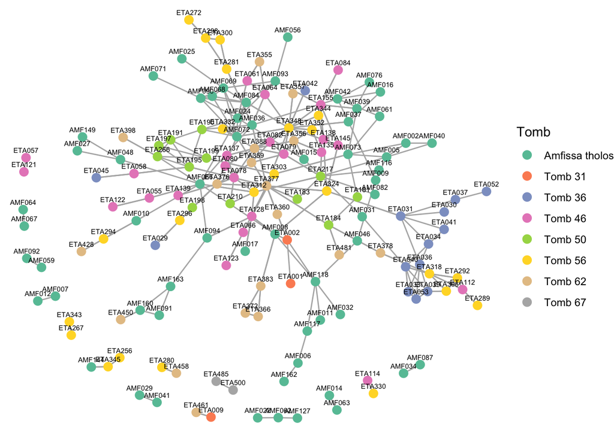

### Separated tombs

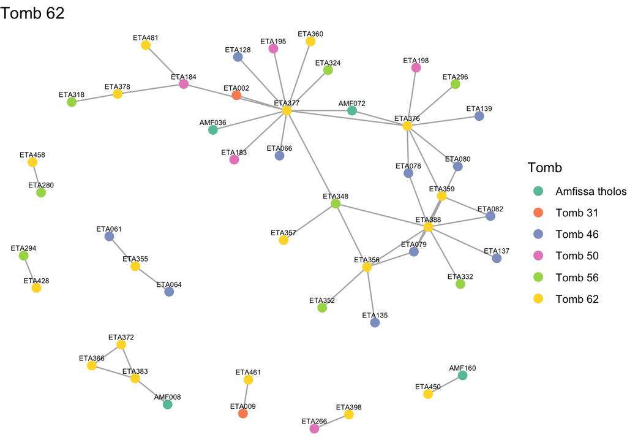

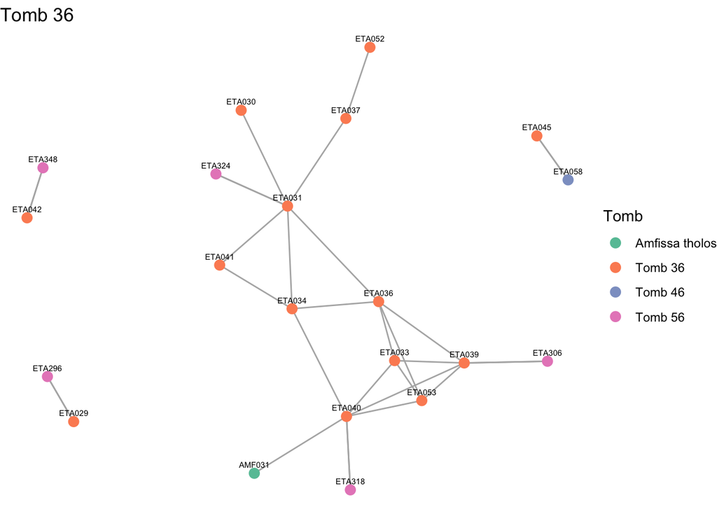

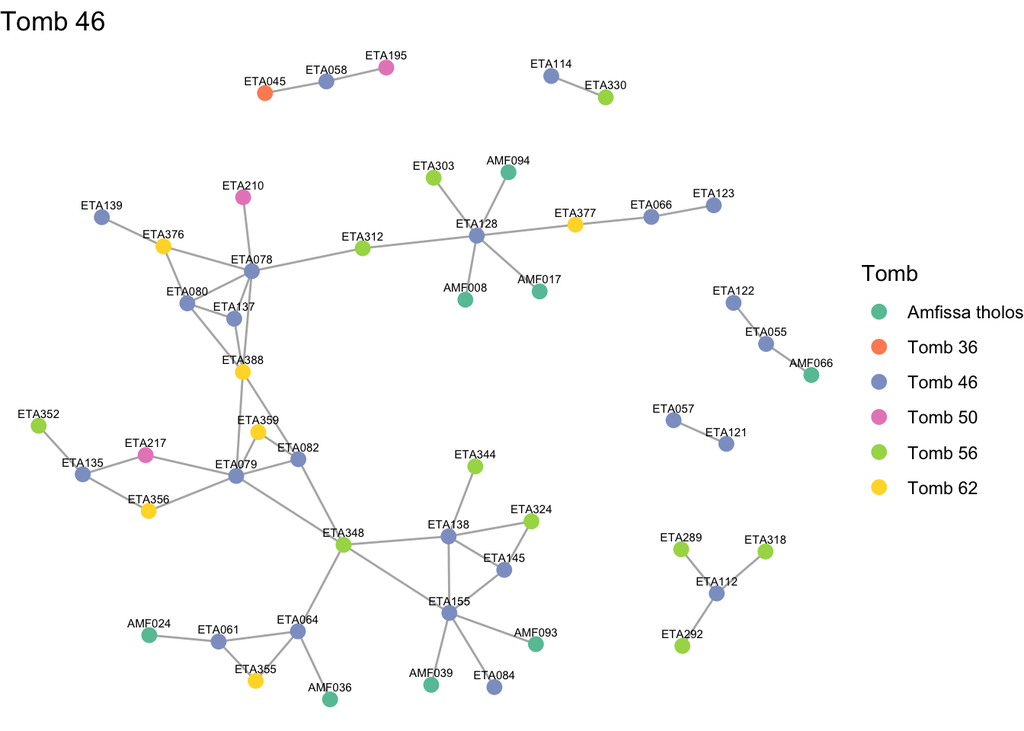

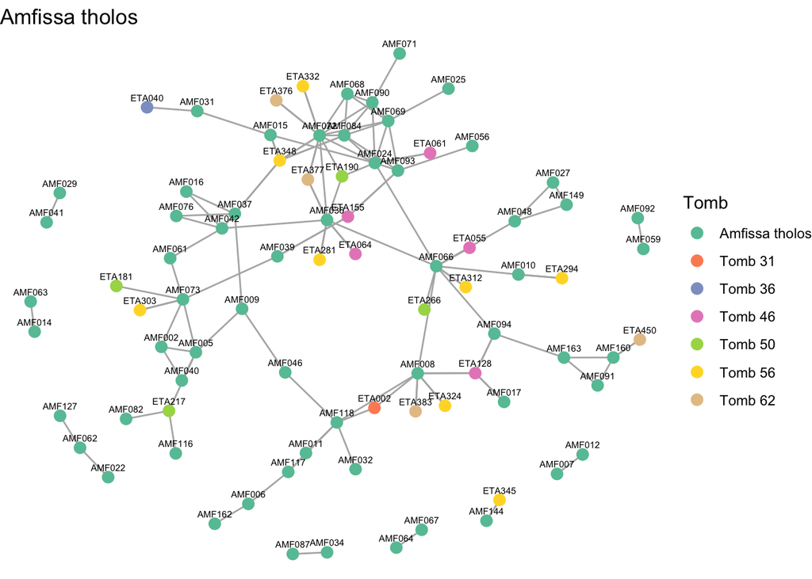

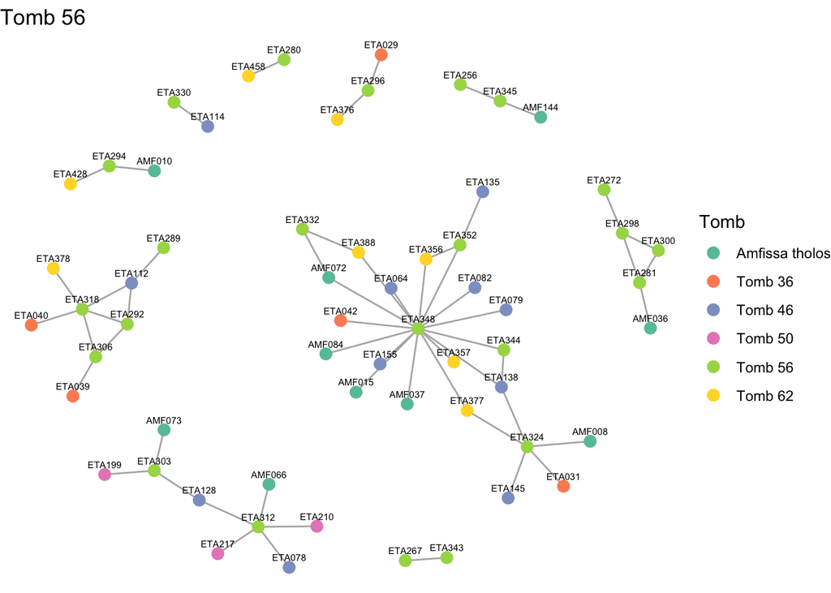

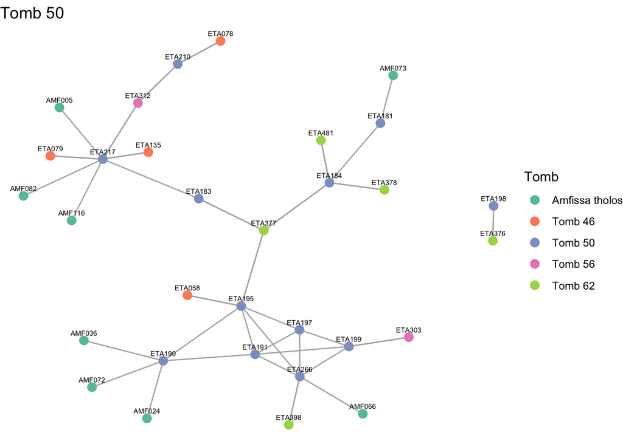

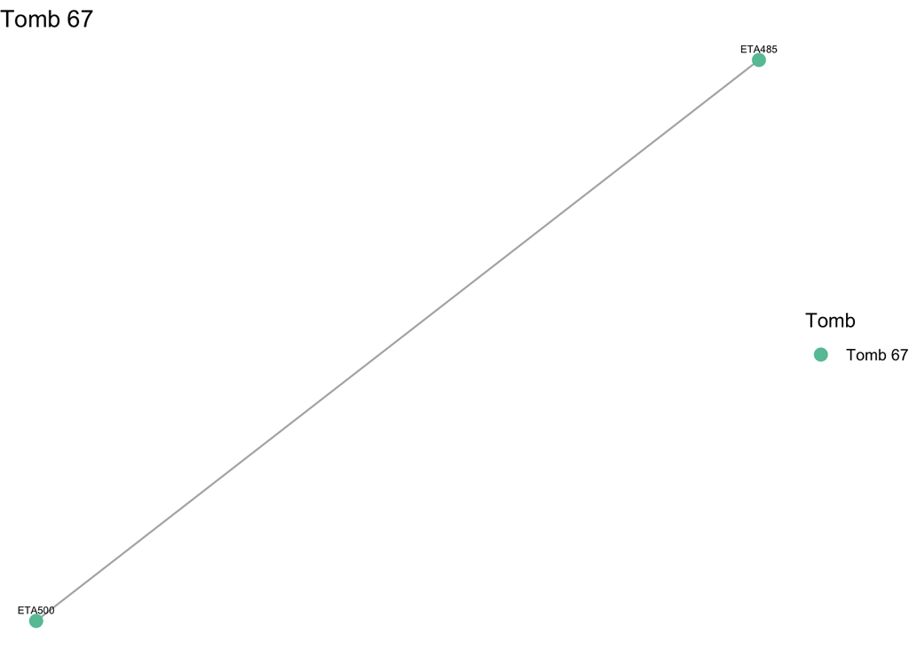

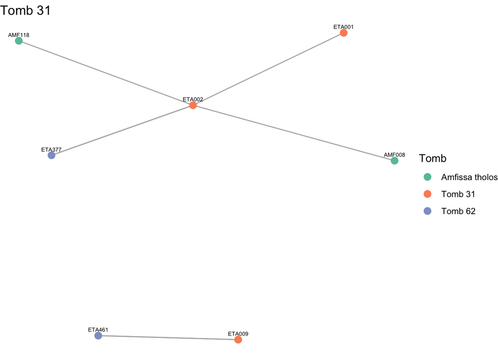

#### Grouped tomb 46 56 62 version

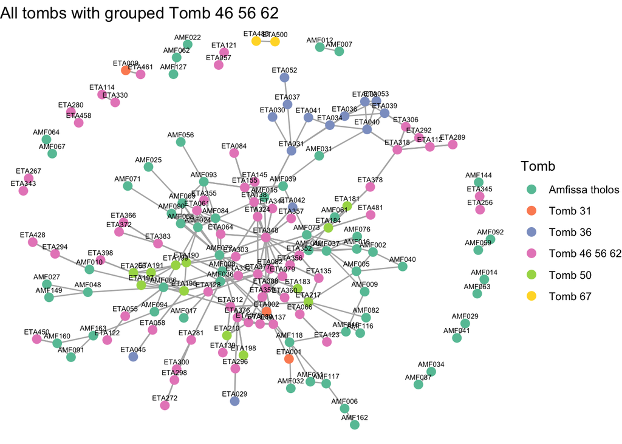

#### Tomb 46 56 62 only

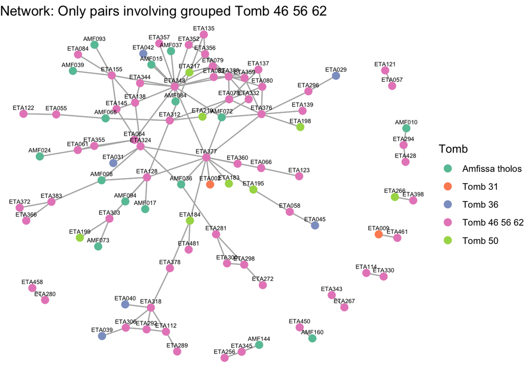

**Comment:**

- Different ratio in whether the related pairs or in the same tombs or in different tombs
- But just by looking, some tombs really point out that they tends to have internal relatedness more than random relatedness to different tombs.